# Modelling the Brain’s Response to Visual Stimuli

## Modeling

For each of our models, our goal is to predict the response to the viewing of an image for each of the 1,294 voxels (cubic region in the brain).

That is, we have 1,294 separate models (one for each voxel), where the predictors/variables correspond to the 10,921 Gabor features from the training images.

### Feature selection

To make the problem computationally feasible, we decided to filter the 10,921 Gabor features to the 500 that were most correlated with each voxel.

To identify the correlation of each Gabor feature with each voxel response, we ran the following code (contained in the `code/voxel_cor.R` file) on the statistics department computer cluster at UC Berkeley. You could probably run it on your laptop, but I would advise against it unless you are incredibly patient.

```r
library(parallel)
nCores <- 24  # to set manually
cl <- makeCluster(nCores)
# export the necessary variables
clusterExport(cl, c("train.feat", "train.resp", "glmnet"),
              envir=environment())
# calcualte the correlation of each variable with each voxel
cor.vox <- parLapply(cl, data.frame(train.resp), function(voxel) {
  apply(train.feat, 2, function(feature) cor(voxel, feature))
})
# save the results
save(cor.vox, file = "results/voxel_cor.RData")
```

Next, to identify the 500 Gabor features that are most correlated with each voxel, we can simply run the following code.

```r
# identify the 500 most correlated features for each variable
top.features <- lapply(cor.vox, function(cor) {
  order(cor, decreasing = TRUE)[1:500]
})
```

## Random Forest

For comparison, we ran a RF model on each voxel using the top 500 Gabor features. The following code was run on the SCF cluster.

```r
library(randomForest)
```

```r
library(parallel)
nCores <- 24  # to set manually
cl <- makeCluster(nCores)
# run random forest for each of the voxel lists
clusterExport(cl, c("train.resp", "train.feat",
                    "randomForest", "top.features"),
              envir=environment())
rf.list <- parLapply(cl, 1:ncol(train.resp), function(voxel) {
  randomForest(x = train.feat[, top.features[[voxel]]],
               y = train.resp[, voxel],
               ntree = 100)
})
save(rf.list, file = "results/rf_results_top500.RData")
```

The code below load the saved results data file.

```r
# calculate the predicted voxel responses for each image in the VALIDATION set
rf.predictions <- lapply(1:ncol(val.resp), function(voxel) {
  voxel.val <- val.feat[, top.features[[voxel]]]
  #colnames(voxel.val) <- paste0("X", 1:ncol(voxel.val))
  predict(rf.list[[voxel]], voxel.val)
})
```

Next, we can plot a histogram of the correlation of the true voxel responses with the predicted voxel responses for each of the 1,294 voxels.

```r
# calculate the correlation between the predictions and the true responses for each voxel
rf.prediction.cor <- sapply(1:ncol(val.resp), function(voxel) {
  cor(rf.predictions[[voxel]], val.resp[ ,voxel])
})
# convert to data frame
rf.prediction.cor <- data.frame(voxel = 1:length(rf.prediction.cor), cor = rf.prediction.cor)
```

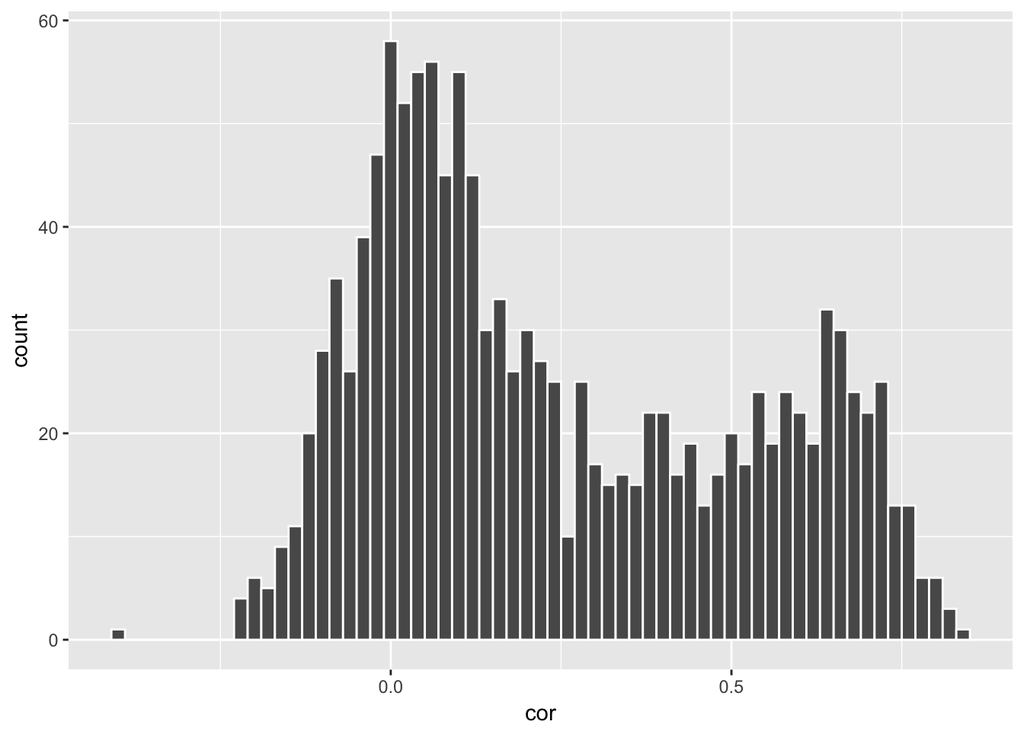

```r
# plot a histogram of the correlations between the true and predicted voxel responses
ggplot(rf.prediction.cor) + geom_histogram(aes(x = cor), col = "white", binwidth = 0.02)
```

We find that there are two groups of voxel clusters where the first group of voxels have correlation close to zero, and the second group has correlation around 0.6.

### Single-voxel performance

```r
set.seed(1348979435)
# randomly select the voxel to view
voxel <- rf.prediction.cor %>% filter(cor > 0.5) %>%
  select(voxel) %>% unlist %>% sample(1) %>% as.vector
voxel
## [1] 968
```

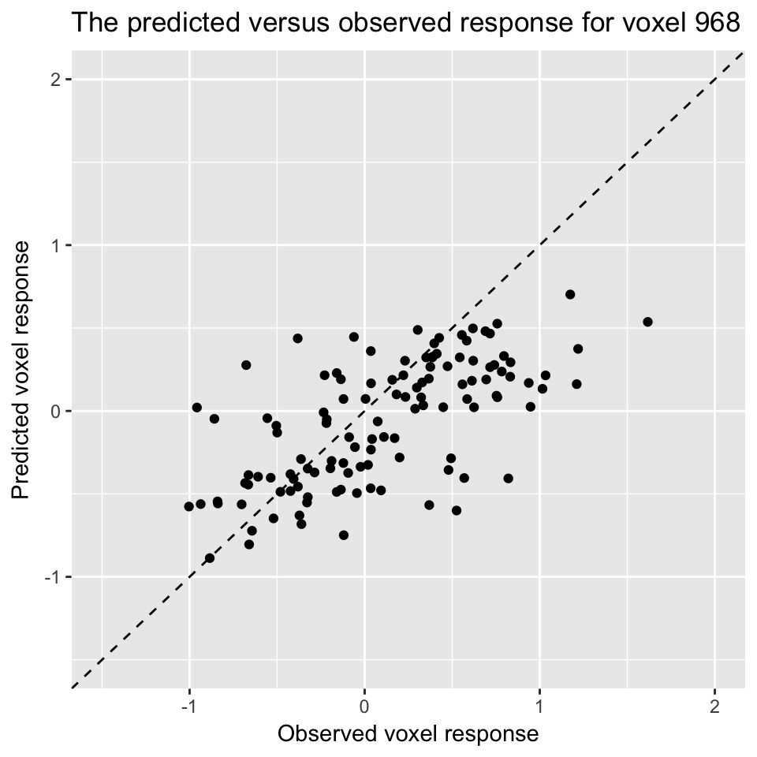

```r
# extract the predictions
rf.predictions.df <- data.frame(pred = rf.predictions[[voxel]],
                             obs = val.resp[, voxel])
# plot predicted vs observed response
ggplot(rf.predictions.df) + geom_point(aes(x = obs, y = pred)) +
  scale_x_continuous(limits = c(-1.5, 2), name = "Observed voxel response") +
  scale_y_continuous(limits = c(-1.5, 2), name = "Predicted voxel response") +
  geom_abline(slope = 1, intercept = 0, linetype = "dashed") +
  ggtitle(paste("The predicted versus observed response for voxel", voxel))
```

```r
rf.prediction.cor %>% filter(voxel == 968)
##   voxel       cor
## 1   968 0.6482504
```

```r
set.seed(384653)
# calculate row clusters
image.clusters <- kmeans(val.resp, centers = 2)$cluster
gabor.clusters <- kmeans(t(val.feat[, top.features[[voxel]]]), centers = 2)$cluster
# calcualte column clusters
voxel.clusters <- kmeans(t(val.resp), centers = 2)$cluster
```

```r
library(plotrix)
response.size <- color.scale(val.resp[, voxel])
feature.sample <- sort(sample(1:500, 50))
# plot a heatmap of the selected features
png(file = "../../Figures/rf-validation-vox968.png",
    height = 1000, width = 800)
superheat(val.feat[, top.features[[voxel]][feature.sample]],

          heat.pal = brewer.pal(5, "RdBu"),

          yr = rf.predictions[[voxel]] - val.resp[, voxel],
          yr.axis.name = "Voxel response\nprediction error",
          yr.obs.col = response.size,
          yr.plot.size = 0.6,

          yt = rf.list[[voxel]]$importance[feature.sample],
          yt.bar.col = "grey",
          yt.plot.type = "bar",
          yt.line.col = "orange",
          smooth.se = FALSE,
          yt.axis.name = "Variable importance",

          order.rows = order(rf.predictions[[voxel]]),
          column.title = "Gabor wavelet features\n(ordered by correlation with vox response)",
          row.title = "Validation set images\n(ordered by predicted vox response)",
          bottom.label = "none",
          left.label = "none")
dev.off()
```

### Visualizing voxel performance accross all voxels

The previous section focused on the model performance of a single voxel. Next, our goal is to simultaneously evaluate the performance of all 1294 voxels.

Next, we plot a heatmap of the *response* matrix, that is, the response of each voxel to each image. Above each column in the heatmap (each column corresponds to a voxel), we plot the correlation of the observed voxel response with the predicted voxel response.

```r
png(file = "../../Figures/rf-validation-all.png",
    height = 800, width = 1100)
superheat(val.resp,

          heat.pal = brewer.pal(5, "RdBu"),

          yt = rf.prediction.cor$cor,
          yt.axis.name = "Correlation between\npredicted and true\nvoxel responses",
          yt.obs.col = rep("slategray4", ncol(val.resp)),
          yt.point.alpha = 0.6,
          yt.axis.name.size = 24,
          yt.axis.size = 24,
          yt.plot.size = 1,


          legend.height = 0.2,
          legend.text.size = 24,
          legend.width = 3,

          membership.rows = image.clusters,
          membership.cols = voxel.clusters,

          left.label = "none",
          bottom.label = "none",
          grid.hline.col = "white",
          grid.vline.col = "white",
          grid.hline.size = 2,
          grid.vline.size = 2,

          row.title = "Validation images (120)",
          row.title.size = 10,
          column.title = "Voxels (1,294)",
          column.title.size = 10,

          title = "(a)",
          title.size = 12)
dev.off()
```

```r
png(file = "../../Figures/rf-validation-all-smooth.png",
    height = 800, width = 1100)
superheat(val.resp,
          X.text = matrix(c("decreased\nvoxel\nresponse", "increased\nvoxel\nresponse", "neutral\nvoxel\nresponse", "neutral\nvoxel\nresponse"), ncol = 2),
          X.text.col = matrix(c("white", "white", "black", "black"), ncol = 2),
          X.text.size = 8,

          heat.pal = brewer.pal(5, "RdBu"),

          yt = rf.prediction.cor$cor,
          yt.axis.name = "Correlation between\npredicted and true\nvoxel responses",
          yt.plot.type = "boxplot",
          yt.cluster.col = "slategray4",
          yt.axis.name.size = 24,
          yt.axis.size = 24,
          yt.plot.size = 0.8,

          legend.height = 0.2,
          legend.text.size = 24,
          legend.width = 3,


          membership.rows = image.clusters,
          membership.cols = voxel.clusters,

          left.label = "none",
          bottom.label = "none",
          grid.hline.col = "white",
          grid.vline.col = "white",

          grid.hline.size = 2,
          grid.vline.size = 2,

          smooth.heat = T,
          row.title = "Validation images (120)",
          row.title.size = 10,
          column.title = "Voxels (1,294)",
          column.title.size = 10,

          title = "(b)",
          title.size = 12)
dev.off()
```

## Exploring the voxel clusters

Notice that we found two clusters of voxels that respond to the visual stimuli differently: the first cluster of voxels is highly sensitive to visual stimuli, whereas the second cluster is not.

Our goal is to explore the physical locations of the voxels. We can load in the locations data that can be found on Yuval Benjamini’s [website](http://statweb.stanford.edu/~yuvalben/stat312/dataset_1/v1_locations.RData).

```r
load("raw_data/v1_locations.RData")
# v1 locations
dim(v1_locations)
## [1] 1331    3
head(v1_locations)
##      [,1] [,2] [,3]
## [1,]   34   22    3
## [2,]   34   23    3
## [3,]   34   24    3
## [4,]   34   25    3
## [5,]   34   26    3
## [6,]   34   20    4
```

Note that `v1_locations` appears to hold the (x, y, z)-locations of each V1 voxel. However, recall that we had a number of voxels with mostly missing values. We remove these from our location data frame below.

```r
v1.locations <- as.data.frame(v1_locations[which(missing.variables == 0), ])
colnames(v1.locations) <- c("x", "y", "z")
v1.locations$cluster <- factor(voxel.clusters)
v1.locations$cor = rf.prediction.cor$cor
rm(v1_locations)
```

Next, we can plot the voxels in space.

```r
library(plotly)
voxel.clusters <- factor(paste("cluster", voxel.clusters))
plot_ly(v1.locations, x = ~x, y = ~y, z = ~z,
        color = ~cluster,
        size = ~cor,
        type = "scatter3d",
        mode = "markers",
        marker = list(colors = c('#BF382A', '#0C4B8E'),
                      size = c(),
                      line = list(color = 'grey', width = 1.5))) %>%
  layout(scene = list(xaxis = list(title = 'x'),
                   yaxis = list(title = 'y'),
                   zaxis = list(title = 'z')))
```

[interactive chart not shown]